# R for Reproducible Scientific Analysis

# Introducing `map

The function we are going to introduce next is going to allow us to repeat the same function for different subsets of our data. The same result can be accomplished with writing a loop, but the function we will consider next hides all of the “housekeeping” details (related to iterators and allocation of the output vector) and leaves only essential elements for the user to specify.

```r
`map(<DATA>, <FUNCTION>)'
```

What the function requires is the list (or vector) of data and a name of the function you want to apply to each element of your data.

> **NOTE:** Simplest behaviour can be observed by calling a `map` function on a vector. Vector will be authomatically transformed to list and operation will be performed on each element of this list (i.e. on each element of the original vector).

> If you specify the dataframe in place of `<DATA>`, because dataframe is a list of columns, function will be performed on columns.

> If you want the function to operate in the slices of your dataframe (think of `group by` behavior) you will have to split the dataframe into the list of smaller dataframes, with each element containing only the data related to one slice.

```r
# function sqrt applied to each element of the vector, output expected as a numeric vector
1:3 %>% map_dbl(sqrt)
```

```
## [1] 1.000000 1.414214 1.732051
```

```r
# list of columns in, list of column means out
gapminder %>% select(year, gdpPercap, lifeExp) %>%
  map(mean)
```

```
## $year
## [1] 1979.5
##
## $gdpPercap
## [1] 7215.327
##
## $lifeExp
## [1] 59.47444
```

```r
# vector in, new variable out
gapminder %>%
  mutate(gdpBillions = map2_dbl(gdpPercap , pop, function(x, y) x*y/10^9))
```

```
## # A tibble: 1,704 x 7
##        country continent  year lifeExp      pop gdpPercap gdpBillions
##         <fctr>    <fctr> <int>   <dbl>    <int>     <dbl>       <dbl>
##  1 Afghanistan      Asia  1952  28.801  8425333  779.4453    6.567086
##  2 Afghanistan      Asia  1957  30.332  9240934  820.8530    7.585449
##  3 Afghanistan      Asia  1962  31.997 10267083  853.1007    8.758856
##  4 Afghanistan      Asia  1967  34.020 11537966  836.1971    9.648014
##  5 Afghanistan      Asia  1972  36.088 13079460  739.9811    9.678553
##  6 Afghanistan      Asia  1977  38.438 14880372  786.1134   11.697659
##  7 Afghanistan      Asia  1982  39.854 12881816  978.0114   12.598563
##  8 Afghanistan      Asia  1987  40.822 13867957  852.3959   11.820990
##  9 Afghanistan      Asia  1992  41.674 16317921  649.3414   10.595902
## 10 Afghanistan      Asia  1997  41.763 22227415  635.3414   14.121996
## # ... with 1,694 more rows
```

As you have seen above, we can use `map()` to apply a linear model to element of our complex `data` column. We will compute the results in a newly created variable in the `by_country` data frame with `mutate()`.

```r
by_country <- by_country %>%
  mutate(model = purrr::map(data, ~lm(formula = lifeExp ~ year, data = .x)))
by_country
```

```
## # A tibble: 142 x 4
##        country continent              data    model
##         <fctr>    <fctr>            <list>   <list>
##  1 Afghanistan      Asia <tibble [12 x 4]> <S3: lm>
##  2     Albania    Europe <tibble [12 x 4]> <S3: lm>
##  3     Algeria    Africa <tibble [12 x 4]> <S3: lm>
##  4      Angola    Africa <tibble [12 x 4]> <S3: lm>
##  5   Argentina  Americas <tibble [12 x 4]> <S3: lm>
##  6   Australia   Oceania <tibble [12 x 4]> <S3: lm>
##  7     Austria    Europe <tibble [12 x 4]> <S3: lm>
##  8     Bahrain      Asia <tibble [12 x 4]> <S3: lm>
##  9  Bangladesh      Asia <tibble [12 x 4]> <S3: lm>
## 10     Belgium    Europe <tibble [12 x 4]> <S3: lm>
## # ... with 132 more rows
```

```r
glance_df <- by_country %>%
  mutate(glance = map(model, broom::glance)) %>%
  unnest(glance, .drop = TRUE)
glance_df
```

```
## # A tibble: 142 x 13
##        country continent r.squared adj.r.squared     sigma  statistic
##         <fctr>    <fctr>     <dbl>         <dbl>     <dbl>      <dbl>
##  1 Afghanistan      Asia 0.9477123     0.9424835 1.2227880  181.24941
##  2     Albania    Europe 0.9105778     0.9016355 1.9830615  101.82901
##  3     Algeria    Africa 0.9851172     0.9836289 1.3230064  661.91709
##  4      Angola    Africa 0.8878146     0.8765961 1.4070091   79.13818
##  5   Argentina  Americas 0.9955681     0.9951249 0.2923072 2246.36635
##  6   Australia   Oceania 0.9796477     0.9776125 0.6206086  481.34586
##  7     Austria    Europe 0.9921340     0.9913474 0.4074094 1261.29629
##  8     Bahrain      Asia 0.9667398     0.9634138 1.6395865  290.65974
##  9  Bangladesh      Asia 0.9893609     0.9882970 0.9766908  929.92637
## 10     Belgium    Europe 0.9945406     0.9939946 0.2929025 1821.68840
## # ... with 132 more rows, and 7 more variables: p.value <dbl>, df <int>,
## #   logLik <dbl>, AIC <dbl>, BIC <dbl>, deviance <dbl>, df.residual <int>
```

With this data frame in hand, we can start to look for models that don’t fit well:

```r
glance_df %>%
  arrange(r.squared)
```

```
## # A tibble: 142 x 13
##             country continent  r.squared adj.r.squared    sigma statistic
##              <fctr>    <fctr>      <dbl>         <dbl>    <dbl>     <dbl>
##  1           Rwanda    Africa 0.01715964  -0.081124401 6.558269 0.1745923
##  2         Botswana    Africa 0.03402340  -0.062574259 6.112177 0.3522177
##  3         Zimbabwe    Africa 0.05623196  -0.038144842 7.205431 0.5958240
##  4           Zambia    Africa 0.05983644  -0.034179918 4.528713 0.6364471
##  5        Swaziland    Africa 0.06821087  -0.024968046 6.644091 0.7320419
##  6          Lesotho    Africa 0.08485635  -0.006658011 5.933934 0.9272463
##  7    Cote d'Ivoire    Africa 0.28337240   0.211709644 3.925590 3.9542491
##  8     South Africa    Africa 0.31246865   0.243715518 4.744356 4.5447914
##  9           Uganda    Africa 0.34215382   0.276369202 3.187668 5.2011219
## 10 Congo, Dem. Rep.    Africa 0.34820278   0.283023054 2.429489 5.3421948
## # ... with 132 more rows, and 7 more variables: p.value <dbl>, df <int>,
## #   logLik <dbl>, AIC <dbl>, BIC <dbl>, deviance <dbl>, df.residual <int>
```

The worst models all appear to be in Africa. Let’s double check that with a plot. Here we have a relatively small number of observations and a discrete variable, so `geom_jitter()` is effective:

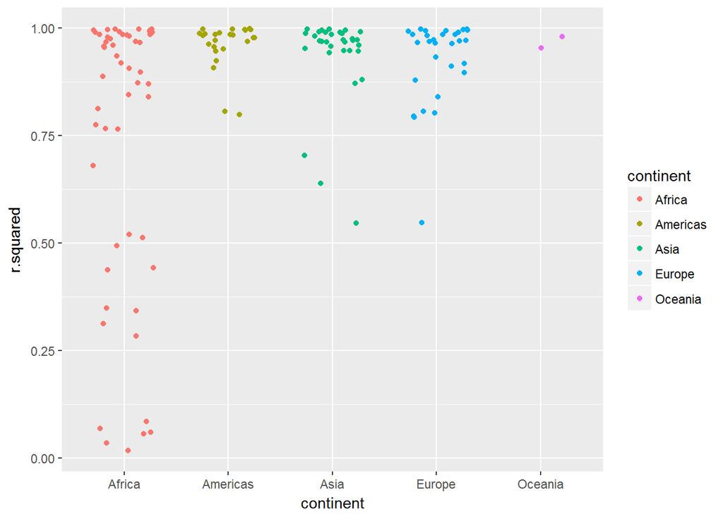

```r
glance_df %>%
  ggplot() +
    geom_jitter(mapping = aes(x = continent, y = r.squared, color = continent), width = 0.3)
```

We could pull out the countries with particularly bad R<sup>2</sup> and plot the data:

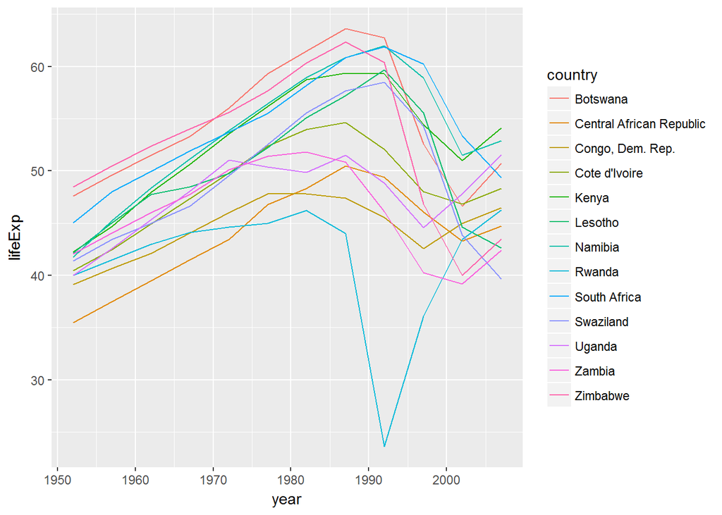

```r
bad_fit <- glance_df %>%
  filter(r.squared < 0.5)

gapminder %>%
  semi_join(bad_fit, by = "country") %>%
  ggplot() +
    geom_line(mapping = aes(x = year, y = lifeExp, colour = country))
```

We see two main effects here: the tragedies of the HIV/AIDS epidemic and the Rwandan genocide.